# HW 02: Education & median income in US Counties

Simulation-Based Inference for the slope

# Introduction

In this homework, you will use simple linear regression to examine the association between the percent of adults with a bachelor’s degree and the median household income for counties in the United States.

## Learning goals

In this assignment, you will…

- Fit and interpret simple linear regression models.
- Conduct simulation-based statistical inference for the population slope, $\beta_1$
- Continue developing a workflow for reproducible data analysis.

# Getting started

- Go to https://rstudio.collegeofidaho.edu and login with your College of Idaho Email and Password.
- Make a subfolder called `hw02` in your `hw` directory to store this homework.
- Log into [Canvas](https://cofi.instructure.com/courses/17093/assignments/202860), navigate to Homework 2 and upload the `hw-02.qmd` and `us-counties-sample.csv` files into the folder your just made.

# Packages

The following packages will be used in this assignment:

```r
library(tidyverse) # for data wrangling
library(ggformula) # for plotting
# load other packages as needed
library(mosaic)
library(broom)
library(knitr)
library(infer)
```

# Data: US Counties

The data are from the `county_2019` data frame in the [usdata](https://openintrostat.github.io/usdata/index.html) R package. These data were originally collected in the 2019 [American Community Survey](https://www.census.gov/programs-surveys/acs) (ACS), an annual survey conducted by the United States Census Bureau that collects demographics and other information from a sample of households in the United States. The data in `county_2019` are county-level statistics from the ACS.

The primary variables you will use are the following:

- `bachelors`: Percent of population 25 years old and older that earned a Bachelor’s degree or higher
- `median_household_income`: Median household income in US dollars
- `household_has_computer`: Percent of households that have desktop or laptop computer

[Click here](https://openintrostat.github.io/usdata/reference/county_2019.html) for the full codebook for the `county_2019` data set.

# Exercises

There has been a lot of conversation recently about the impact of graduating college, i.e., obtaining a bachelor’s degree, on one’s future career and lifetime earnings. The common sentiment is that individuals who have earned a bachelor’s degree (or higher) will earn more income over the course of a lifetime than an individual who does not have such a degree.

The culmination of individual factors can impact the wealth and resources of a county. Therefore will examine the association between these two factors at a county level and use the percent of adults 25 years old + with a Bachelor’s degree to understand variability in the median income. Specifically we’d like to answer such as, “do counties that have a higher percentage of college graduates have higher median household incomes, on average, compared to counties with a lower percentage of college graduates?”.

**Important**

All narrative should be written in complete sentences, and all visualizations should have informative titles and axis labels.

### Exercise 0

Load the `us-counties-sample.csv` into a data frame called `county_data_sample`.

```r
counties <- read_csv("~/MAT-212/hw/hw02/us-counties-sample.csv")
```

## Part 1: Exploratory data analysis

### Exercise 1

Create a histogram of the distribution of the predictor variable `bachelors`and calculate appropriate summary statistics. Use the visualization and summary statistics to describe the distribution. Include an informative title and axis labels on the plot.

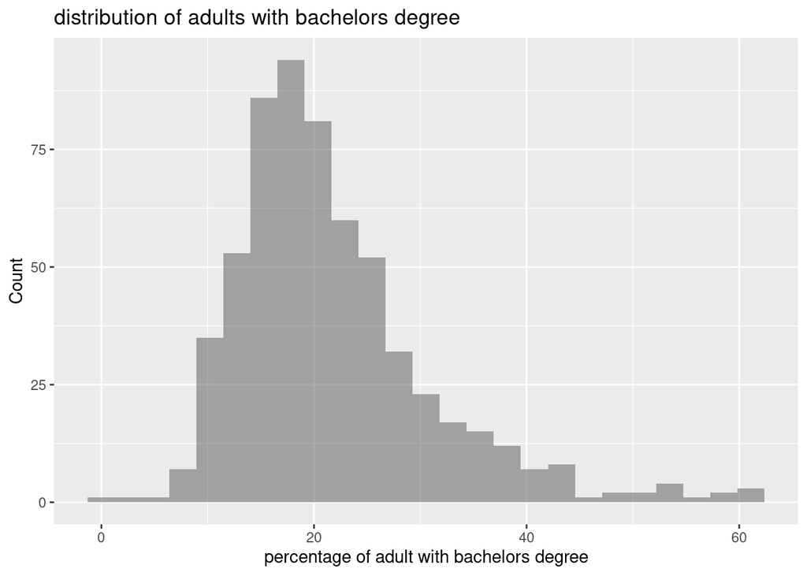

```r
gf_histogram(~bachelors, data =  counties) |>
   gf_labs(x = "percentage of adult with bachelors degree",
       y = "Count",
       title = "distribution of adults with bachelors degree")
```

```r
summary(counties)
```

[output not shown]

[output cut: 184 more lines]

[output not shown]

### Exercise 2

Create a visualization of the relationship between `bachelors` and `median_household_income` and use the `cor` function to calculate the correlation. You will likely want to load the `mosaic` package. It is considered good form to load your packages at the beginning of the document so scroll up to the top and load `mosaic` there. Use the visualization and correlation to describe the relationship between the two variables.

**Tip**

Recall the analysis objective stated at the beginning of the Exercises section.

**Tip**

If you haven’t yet done so, now is a good time to render your document.

[figure not shown]

```r
gf_point(median_household_income~bachelors, data = counties) |>
  gf_labs(x = "median household income",
          y = "adults with bachelors degree",
          title = "relation between people with bachelors degree and median household income")
```

```r
cor(bachelors~median_household_income, data = counties)
```

```
[1] 0.7123457
```

## Part 2: Modeling

### Exercise 3

We will use a linear regression model to better quantify the relationship between `bachelors` and `median_household_income`.

Write the form of the statistical model the researchers would like to estimate using the template below. Use mathematical notation (i.e. with Greek letters) and variable names (`bachelors` and `median_household_income`) in the equation. Note, I’m not asking you to fit the model yet. Replace each word in the equation below with either the name of a variable or a Greek letter.

$$median\_household\_income = \beta_0 + \beta_1 * bachelors + \epsilon$$

**Tip**

[Click here](https://oeis.org/wiki/List_of_LaTeX_mathematical_symbols) for a guide on writing mathematical symbols using LaTeX. You will need to use a backslash (\) before each underscore in the LaTeX code. For example, `avg_air_temp` will be written as *avg\_air\_temp.*

### Exercise 4

- Fit the regression line corresponding to the statistical model in the previous exercise. Use `tidy` and `kable` to neatly display the model output using 3 digits. Note you will need to load the `broom` package before you can use the `tidy` function.

  ```r
  lm_fit <- lm(median_household_income~bachelors, data = counties)
  tidy(lm_fit) |>
    kable(digits=3)
  ```

  | term | estimate | std.error | statistic | p.value |
  | --- | --- | --- | --- | --- |
  | (Intercept) | 30155.530 | 1011.886 | 29.801 | 0 |
  | bachelors | 1064.276 | 42.879 | 24.820 | 0 |

- Write the equation of the fitted model using mathematical notation. Use variable names (`bachelors` and `median_household_income`) in the equation. Hint: Copy and paste your answer from the previous exercise, fill in the $\beta$’s with numbers, and remove the error term.

  $$median\_household\_income = 30155.530 + 1064.276 * bachelors + \epsilon$$

### Exercise 5

- Interpret the slope. The interpretation should be written in a way that is meaningful in the context of the data.

  For every 1% increase in the percentage in bachelors will result in $1064.276 increase in the median_household_income.
- Is it useful to interpret the intercept for this data? If so, write the interpretation in the context of the data. Otherwise, briefly explain why not.

  Yes, it is useful to interpret the intercept because that says, if the percentage of bachelors is 0%, then the median income of a household is $30155.530 which is possible.

**Tip**

Now is a good time to render your document again if you haven’t done so recently.

## Part 3: Inference for the U.S.

We want to use the data from these 600 randomly selected counties to draw conclusions about the relationship between the percent of adults age 25 and older with a bachelor’s degree and median household income for the over 3,000 counties in the United States.

### Exercise 6

- What is the population of interest? What is the sample?

  Population of interest is over 3000 counties in the US. this sample is 600 randomly selected counties from the US.
- Is it reasonable to treat the sample in this analysis as representative of the population? Briefly explain why or why not. If you have never taken a statistics course before, I encourage you to read subsections [2.1.4](https://openintro-ims.netlify.app/data-design#sampling-from-a-population) and [2.1.5](https://openintro-ims.netlify.app/data-design#sec-samp-methods) from [Introduction to Modern Statistics](https://openintro-ims.netlify.app/). Don’t worry, they’re very short.

  Yes, it is reasonable to treat the sample in this analysis as representative of the population. it is because they are selected randomly and without any bias.

### Exercise 7

Conduct a hypothesis test for the slope to assess whether there is sufficient evidence of a linear relationship between the percent of adults age 25 and older with a bachelor’s degree and the median household income in a county. Use a randomization (permutation) test. Remember that you’ll need to load the `infer` package. In your response:

- State the null and alternative hypotheses in words and mathematical notation

  $$H_o : \beta_1 = 0$$

  There is no relationship between the percent of adults age 25 and older with a bachelor’s degree and the median household income in a county.

  $$H_o : \beta_1 \neq 0$$

  There is a relationship between the percent of adults age 25 and older with a bachelor’s degree and the median household income in a county.
- Show all relevant code and output used to conduct the test. Use `set.seed(2025)` and 1000 iterations to construct the appropriate distribution.

  boot_fits
  ```

- State the conclusion in the context of the data.

### Exercise 8

Next, construct a 95% confidence interval for the slope using bootstrapping with `set.seed(2025)` and 1000 iterations.

- Show all relevant code and output used to calculate the interval.

  ```r
  observed_fit <- counties |>
    specify(median_household_income ~ bachelors) |>
    fit()

  conf_int <- get_confidence_interval(
    boot_fits,
    point_estimate = observed_fit,
    level = 0.95,
    type = "percentile"
  )

  conf_int
  ```

  ```
  # A tibble: 2 × 3
    term      lower_ci upper_ci
    <chr>        <dbl>    <dbl>
  1 bachelors     953.    1174.
  2 intercept   27899.   32427.
  ```

- Interpret the confidence interval in the context of the data.
- Is the confidence interval consistent with the results of the test from the previous exercise? Briefly explain why or why not.

**Tip**

Now is a good time to render your document again if you haven’t done so recently.

## Conceptual Questions

Please try to answer these concisely and adhere to the sentence maximum.

### Exercise 9

Should all of your classmates get the same 95% confidence interval as you? Max one sentence.

No, because it depends on the bootstrap variations.

### Exercise 10

Why was it necessary to set a seed in the previous two exercises and how does it relate to the concept of reproducibility? Max two sentences.

Seeding ensures consistency in the result process. It produces the same result every time the code is run and makes sure our data is consistent.

### Exercise 11

Would taking a larger sample of counties most likely result in a more or less precise confidence interval? What about a wider or narrower confidence interval? Max one sentence each but you should be able to answer with a single sentence.

Since we know larger samples increases precision based on class discussion and eventually it will make the confidence interval narrower as well because increase in precision.

### Exercise 12

Why would taking a larger sample of counties not impact the accuracy of the 95% confidence interval? How can we increase the accuracy? Max two sentences.

Larger sample size does not mean more accurate information (meme from class). Accuracy depends on unbiased and correct representation and doing so increases accuracy.

### Exercise 13

Explain why the following statement doesn’t make sense: “There is a 95% probability that the population slope is between the two numbers I stated in Exercise 8. Max three sentences.

A 95% confidence interval means that, 95% of the calculated intervals will happen to have the population slope. The given statement says that the population slope has 95% chances of falling within the intervals which is the opposite of what it actually is.

## Reproducibility & Conceptual Questions

### Exercise 14 (Extra Credit)

You are asked to use a reproducible workflow for all of your work in the class, and the goal of this question to is better understand potential real-world implications of doing (or not) doing so. [Here](https://mat212wi25.netlify.app/slides/01-welcome#/when-things-go-wrong) are some real-life examples in which having a non-reproducible workflow resulted in errors that impacted research and public records.

Choose one of the scenarios from the table and read the linked article discussing what went wrong. Then,

- Briefly describe what went wrong, i.e., what part of the process of was not reproducible and what error or impact that had.

  PHE used an old excel file called XLS which only has capacity of 65000 rows instead of millions that Excel is actually capable of. Because of the use of this old format, they ended up having truncation in their data result in loss of data. This data allocation was not reproducible because it was not suited for large data sets.
- Then, describe how the researchers could make the process reproducible.

  They could have simply just used the normal excel sheet format or even better, could have used a database management program like SQL.

**Tip**

Now is a good time to render your document again. Make sure that everything is formatted the way you want it to be.

# Submission

We’ll be submitting HTML files and .qmd files to Canvas.

**Warning**

Before you wrap up the assignment, make sure you have rendered your document and that the HTML file appears as you want it to.

**Tip**

You’re done and ready to submit your work! Render your document and upload the .qmd and .html files to Canvas.

# Grading (20 pts + 2 pts extra credit)

| Component | Points |
| --- | --- |
| Ex 1 | 1 |
| Ex 2 | 1 |
| Ex 3 | 1 |
| Ex 4 | 1 |
| Ex 5 | 1 |
| Ex 6 | 2 |
| Ex 7 | 3 |
| Ex 8 | 3 |
| Ex 9 | 1 |
| Ex 10 | 1 |
| Ex 11 | 1 |
| Ex 12 | 1 |
| Ex 13 | 1 |
| Ex 14 (Extra Credit) | 2 |
| Grammar & Writing | 1[^1] |
| Workflow & formatting | 1[^2] |

## Footnotes

[^1]: The “Grammar & Writing” grade is decided based on your grammar and writing. This is typically decided by choosing one of the questions and assessing the writing.
[^2]: The “Workflow & formatting” grade is to assess the reproducible workflow and document format. This includes having a neatly organized document with readable code and your name and the date in the YAML.